# Analysis Of Obesity Data

Group Members: Darshil Talati, Mustapha Saidykhan, Boluwatife Melitoyitan

## Introduction

Welcome to our comprehensive tutorial on the data science pipeline, where we delve into the fascinating realm of obesity data analysis. In this tutorial, we will guide you through each stage of the data science process, from the initial curation and management of the dataset to the insightful messages derived from our analysis.

Obesity, a growing concern worldwide, presents a multifaceted challenge that can greatly benefit from data-driven insights. By leveraging various techniques ranging from exploratory data analysis to machine learning algorithms, we aim to uncover patterns, correlations, and valuable insights hidden within the data.

Throughout this tutorial, we will demonstrate how to effectively navigate the data science pipeline using Python, integrating Markdown prose to provide clear explanations and instructions. Our tutorial is designed to be accessible to both beginners and those with prior experience in data science, offering a step-by-step approach to understanding and analyzing obesity data.

So, whether you're a novice eager to embark on your data science journey or a seasoned practitioner looking to enhance your skills, join us as we embark on this enlightening exploration of obesity data analysis. Let's dive in!

### Required Imports

Before diving into data curation, parsing, and management, it's essential to import the necessary libraries that will facilitate these processes. Here are some of the most important and common libraries used in data processing:

-Pandas: A powerful data manipulation library that provides data structures and functions needed to manipulate structured data seamlessly.

-NumPy: A library for numerical operations in Python. It provides support for arrays, matrices, and many mathematical functions.

-Matplotlib: A plotting library for creating static, interactive, and animated visualizations in Python.

-Seaborn: A data visualization library based on Matplotlib that provides a high-level interface for drawing attractive statistical graphics.

-Missingno: A library for visualizing missing data in a dataset.

```python
import pandas as pd        # For data manipulation and analysis
import numpy as np         # For numerical operations
import matplotlib.pyplot as plt  # For data visualization
import seaborn as sns      # For statistical data visualization
import missingno as msno   # For visualizing missing data
```

## 1. Data Curation, Parsing, and Management

#### 1.1 Introduction to Data Curation

Data curation is the process of organizing and integrating data collected from various sources. It involves maintaining, preserving, and adding value to the data throughout its lifecycle. Effective data curation ensures that data is accurate, reliable, and accessible for analysis. In the context of a data science project, proper data curation is crucial as it sets the foundation for subsequent stages such as analysis and modeling.

#### 1.2 Dataset Description

Dataset Name: Obesity Data Set

Source: [The dataset is sourced from Kaggle.](https://www.kaggle.com/datasets/aravindpcoder/obesity-or-cvd-risk-classifyregressorcluster)

Description: This dataset contains information related to obesity levels in individuals based on various attributes. The dataset includes demographic information, eating habits, physical activity, and other health-related factors. We'll be loading this dataset into a python [dataframe](https://www.w3schools.com/python/pandas/pandas_dataframes.asp)

Attributes:

```python
# Load the dataset into a python dataframe
data = pd.read_csv('ObesityDataSet.csv')

# Changing column names to improve readability of the dataset
new_column_names = ['Gender', 'Age', 'Height', 'Weight', 'Family History with Overweight', 'Frequent Consumption of High Caloric Food',
                        'Frequency of Vegetable Consumption', 'Number of Main Meals', 'Consumption of Food Between Meals', 'Smoker?',
                        'Consumption of Water daily', 'Monitors Calories?', 'Frequency of Physical Activity', 'Time Using Technology',
                        'Consumption of Alcohol', 'Transportation', 'Obesity Level']
data.columns = new_column_names

# Print number of rows before handling na values
print("Rows before handling nan values: ", data.shape)

data
```

```
Rows before handling nan values:  (2111, 17)
```

|  | Gender | Age | Height | Weight | Family History with Overweight | Frequent Consumption of High Caloric Food | Frequency of Vegetable Consumption | Number of Main Meals | Consumption of Food Between Meals | Smoker? | Consumption of Water daily | Monitors Calories? | Frequency of Physical Activity | Time Using Technology | Consumption of Alcohol | Transportation | Obesity Level |
| --- | --- | --- | --- | --- | --- | --- | --- | --- | --- | --- | --- | --- | --- | --- | --- | --- | --- |
| 0 | Female | 21.000000 | 1.620000 | 64.000000 | yes | no | 2.0 | 3.0 | Sometimes | no | 2.000000 | no | 0.000000 | 1.000000 | no | Public_Transportation | Normal_Weight |
| 1 | Female | 21.000000 | 1.520000 | 56.000000 | yes | no | 3.0 | 3.0 | Sometimes | yes | 3.000000 | yes | 3.000000 | 0.000000 | Sometimes | Public_Transportation | Normal_Weight |
| 2 | Male | 23.000000 | 1.800000 | 77.000000 | yes | no | 2.0 | 3.0 | Sometimes | no | 2.000000 | no | 2.000000 | 1.000000 | Frequently | Public_Transportation | Normal_Weight |
| 3 | Male | 27.000000 | 1.800000 | 87.000000 | no | no | 3.0 | 3.0 | Sometimes | no | 2.000000 | no | 2.000000 | 0.000000 | Frequently | Walking | Overweight_Level_I |
| 4 | Male | 22.000000 | 1.780000 | 89.800000 | no | no | 2.0 | 1.0 | Sometimes | no | 2.000000 | no | 0.000000 | 0.000000 | Sometimes | Public_Transportation | Overweight_Level_II |
| ... | ... | ... | ... | ... | ... | ... | ... | ... | ... | ... | ... | ... | ... | ... | ... | ... | ... |
| 2106 | Female | 20.976842 | 1.710730 | 131.408528 | yes | yes | 3.0 | 3.0 | Sometimes | no | 1.728139 | no | 1.676269 | 0.906247 | Sometimes | Public_Transportation | Obesity_Type_III |
| 2107 | Female | 21.982942 | 1.748584 | 133.742943 | yes | yes | 3.0 | 3.0 | Sometimes | no | 2.005130 | no | 1.341390 | 0.599270 | Sometimes | Public_Transportation | Obesity_Type_III |
| 2108 | Female | 22.524036 | 1.752206 | 133.689352 | yes | yes | 3.0 | 3.0 | Sometimes | no | 2.054193 | no | 1.414209 | 0.646288 | Sometimes | Public_Transportation | Obesity_Type_III |
| 2109 | Female | 24.361936 | 1.739450 | 133.346641 | yes | yes | 3.0 | 3.0 | Sometimes | no | 2.852339 | no | 1.139107 | 0.586035 | Sometimes | Public_Transportation | Obesity_Type_III |
| 2110 | Female | 23.664709 | 1.738836 | 133.472641 | yes | yes | 3.0 | 3.0 | Sometimes | no | 2.863513 | no | 1.026452 | 0.714137 | Sometimes | Public_Transportation | Obesity_Type_III |

2111 rows × 17 columns

## 2. Data Processing

#### 2.1 Data Parsing and Cleaning

Data parsing and cleaning are essential steps to ensure that the data is ready for analysis. This involves handling missing values, correcting errors, and formatting the data properly. (https://www.w3schools.com/python/pandas/pandas_cleaning.asp)

```python
# Handle missing values
# Fill missing numerical values with the mean (if any)
data.fillna(data['Height'].mean(), inplace=True)

# Remove rows with missing categorical values (if any)
data.dropna(subset=['Gender', 'Obesity Level'], inplace=True)

# Correcting errors
# Ensure 'Gender' only contains 'Male' or 'Female'
data['Gender'] = data['Gender'].apply(lambda x: 'Male' if x == 'Male' else ('Female' if x == 'Female' else None))

# Ensure all data is in the correct format for analysis
data['Age'] = data['Age'].astype(int)
data['Height'] = data['Height'].astype(float)
data['Weight'] = data['Weight'].astype(float)

# Convert categorical variables to appropriate types
categorical_columns = ['Gender', 'Family History with Overweight', 'Frequent Consumption of High Caloric Food',
                       'Frequency of Physical Activity', 'Consumption of Alcohol', 'Smoker?', 'Transportation',
                       'Obesity Level']
for col in categorical_columns:
    data[col] = data[col].astype('category')

# Identify and remove duplicate rows if any
data.drop_duplicates(inplace=True)

# Show number of rows after dropping na values
print("Rows after handling nan values: ", data.shape)
data
```

```
Rows after handling nan values:  (2087, 17)
```

|  | Gender | Age | Height | Weight | Family History with Overweight | Frequent Consumption of High Caloric Food | Frequency of Vegetable Consumption | Number of Main Meals | Consumption of Food Between Meals | Smoker? | Consumption of Water daily | Monitors Calories? | Frequency of Physical Activity | Time Using Technology | Consumption of Alcohol | Transportation | Obesity Level |
| --- | --- | --- | --- | --- | --- | --- | --- | --- | --- | --- | --- | --- | --- | --- | --- | --- | --- |
| 0 | Female | 21 | 1.620000 | 64.000000 | yes | no | 2.0 | 3.0 | Sometimes | no | 2.000000 | no | 0.000000 | 1.000000 | no | Public_Transportation | Normal_Weight |
| 1 | Female | 21 | 1.520000 | 56.000000 | yes | no | 3.0 | 3.0 | Sometimes | yes | 3.000000 | yes | 3.000000 | 0.000000 | Sometimes | Public_Transportation | Normal_Weight |
| 2 | Male | 23 | 1.800000 | 77.000000 | yes | no | 2.0 | 3.0 | Sometimes | no | 2.000000 | no | 2.000000 | 1.000000 | Frequently | Public_Transportation | Normal_Weight |
| 3 | Male | 27 | 1.800000 | 87.000000 | no | no | 3.0 | 3.0 | Sometimes | no | 2.000000 | no | 2.000000 | 0.000000 | Frequently | Walking | Overweight_Level_I |
| 4 | Male | 22 | 1.780000 | 89.800000 | no | no | 2.0 | 1.0 | Sometimes | no | 2.000000 | no | 0.000000 | 0.000000 | Sometimes | Public_Transportation | Overweight_Level_II |
| ... | ... | ... | ... | ... | ... | ... | ... | ... | ... | ... | ... | ... | ... | ... | ... | ... | ... |
| 2106 | Female | 20 | 1.710730 | 131.408528 | yes | yes | 3.0 | 3.0 | Sometimes | no | 1.728139 | no | 1.676269 | 0.906247 | Sometimes | Public_Transportation | Obesity_Type_III |
| 2107 | Female | 21 | 1.748584 | 133.742943 | yes | yes | 3.0 | 3.0 | Sometimes | no | 2.005130 | no | 1.341390 | 0.599270 | Sometimes | Public_Transportation | Obesity_Type_III |
| 2108 | Female | 22 | 1.752206 | 133.689352 | yes | yes | 3.0 | 3.0 | Sometimes | no | 2.054193 | no | 1.414209 | 0.646288 | Sometimes | Public_Transportation | Obesity_Type_III |
| 2109 | Female | 24 | 1.739450 | 133.346641 | yes | yes | 3.0 | 3.0 | Sometimes | no | 2.852339 | no | 1.139107 | 0.586035 | Sometimes | Public_Transportation | Obesity_Type_III |
| 2110 | Female | 23 | 1.738836 | 133.472641 | yes | yes | 3.0 | 3.0 | Sometimes | no | 2.863513 | no | 1.026452 | 0.714137 | Sometimes | Public_Transportation | Obesity_Type_III |

2087 rows × 17 columns

## 3. Exploratory Data Analysis (EDA)

Exploratory Data Analysis (EDA) is a critical step in the data science pipeline. It involves summarizing the main characteristics of the data, often using visual methods. EDA helps in understanding the data distribution, detecting anomalies, uncovering patterns, and generating hypotheses for further analysis. The goal of EDA is to gain insights and identify potential relationships between variables. We do EDA mostly through plotting libraries like [matplotlib](https://matplotlib.org/) and other plotting libraries such as [seaborn](https://seaborn.pydata.org/).

### 3.1 Data Visualization

Data visualization is a key component of EDA, as it allows us to see patterns, trends, and outliers that may not be apparent in raw data. We'll use various types of plots to explore the dataset.

##### Histograms

Histograms are used to visualize the distribution of a single numerical variable. They show the frequency of data points within specified ranges (bins). This helps in understanding the shape, central tendency, and spread of the data. For example, a histogram of the Age variable can reveal whether the data is skewed, has outliers, or is normally distributed.

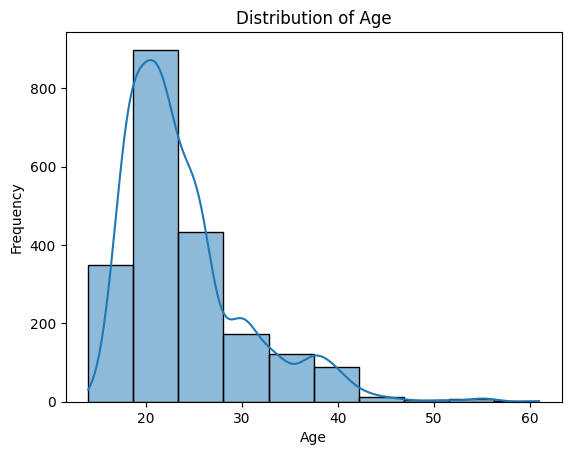

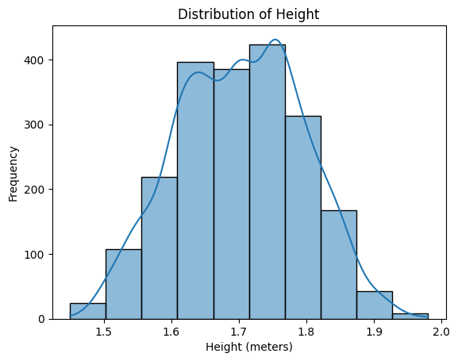

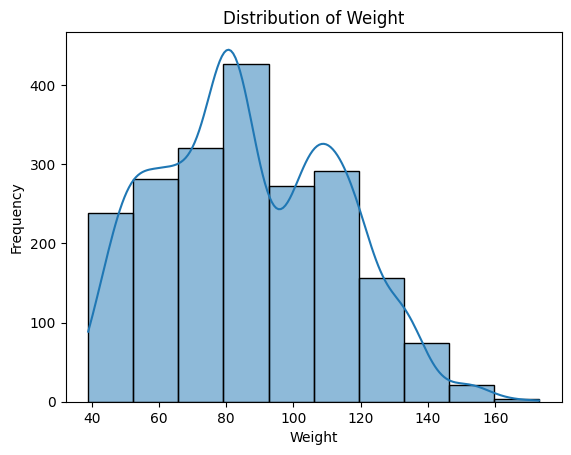

```python
import matplotlib.pyplot as plt
import seaborn as sns

sns.histplot(data['Age'], bins=10, kde=True)
plt.title('Distribution of Age')
plt.xlabel('Age')
plt.ylabel('Frequency')
plt.show()

sns.histplot(data['Height'], bins=10, kde=True)
plt.title('Distribution of Height')
plt.xlabel('Height (meters)')
plt.ylabel('Frequency')
plt.show()

sns.histplot(data['Weight'], bins=10, kde=True)
plt.title('Distribution of Weight')
plt.xlabel('Weight')
plt.ylabel('Frequency')
plt.show()
```

In the code above, sns.histplot is used to create histograms for Age, Height, and Weight. The kde=True parameter adds a Kernel Density Estimate (KDE) line, which smooths the histogram and helps in understanding the probability distribution of the data.

##### Box Plots:

Box plots, also known as whisker plots, are used to visualize the distribution of numerical data and identify outliers. They display the data's quartiles, showing the median, the upper and lower quartiles, and any potential outliers. Box plots are particularly useful for comparing the distribution of a numerical variable across different categories.

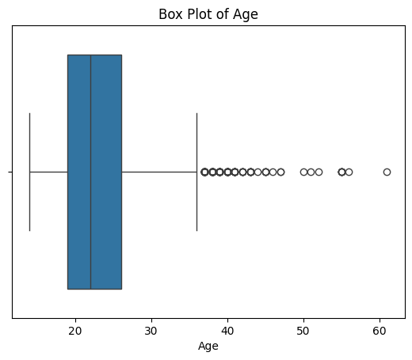

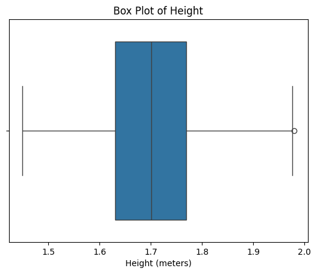

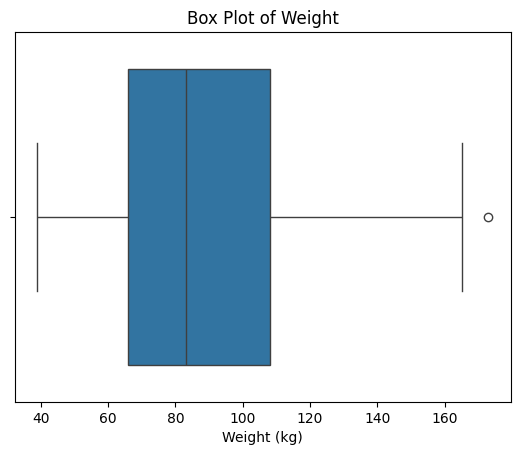

```python
sns.boxplot(x=data['Age'])
plt.title('Box Plot of Age')
plt.xlabel('Age')
plt.show()

sns.boxplot(x=data['Height'])
plt.title('Box Plot of Height')
plt.xlabel('Height (meters)')
plt.show()

sns.boxplot(x=data['Weight'])
plt.title('Box Plot of Weight')
plt.xlabel('Weight (kg)')
plt.show()
```

In the code above, sns.boxplot creates box plots for Age, Height, and Weight. The box represents the interquartile range (IQR), which contains 50% of the data. The line inside the box is the median, and the "whiskers" extend to the minimum and maximum values within 1.5 times the IQR. Outliers are plotted as individual points outside the whiskers.

##### Scatter Plots:

Scatter plots are used to explore the relationship between two numerical variables. Each point on the plot represents an observation from the dataset. Scatter plots can help identify correlations, clusters, and potential outliers. They are particularly useful when investigating potential linear or non-linear relationships between variables.

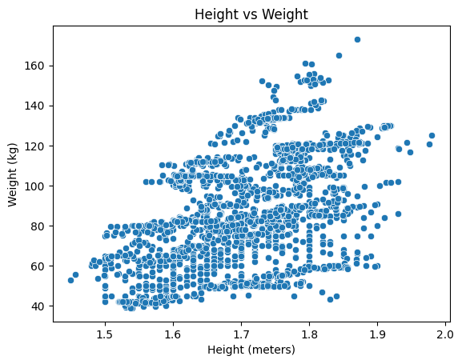

```python
sns.scatterplot(x=data['Height'], y=data['Weight'])
plt.title('Height vs Weight')
plt.xlabel('Height (meters)')
plt.ylabel('Weight (kg)')
plt.show()
```

In the code above, sns.scatterplot creates a scatter plot of Height versus Weight. This visualization can help determine if there is a linear relationship between the height and weight of individuals in the dataset.

##### Bar Plots

Bar plots are used to visualize the distribution of categorical variables. They show the frequency or count of data points in each category. Bar plots are useful for comparing the sizes of different groups and identifying patterns or trends within categorical data.

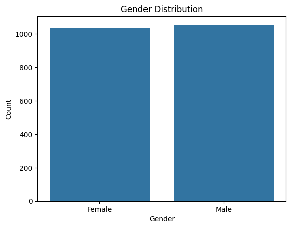

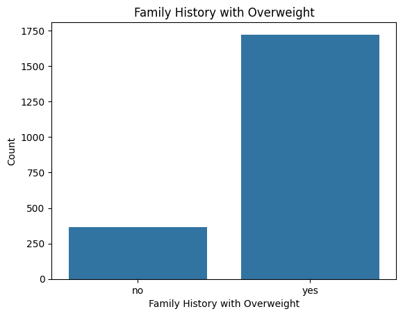

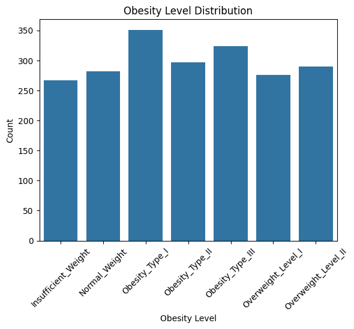

```python
sns.countplot(x=data['Gender'])
plt.title('Gender Distribution')
plt.xlabel('Gender')
plt.ylabel('Count')
plt.show()

sns.countplot(x=data['Family History with Overweight'])
plt.title('Family History with Overweight')
plt.xlabel('Family History with Overweight')
plt.ylabel('Count')
plt.show()

sns.countplot(x=data['Obesity Level'])
plt.title('Obesity Level Distribution')
plt.xlabel('Obesity Level')
plt.ylabel('Count')
plt.xticks(rotation=45)
plt.show()
```

In the code above, sns.countplot is used to create bar plots for Gender, Family History with Overweight, and Obesity Level. The height of each bar represents the count of data points in each category, providing a clear visual comparison of the distribution of these categorical variables.

### 3.3 Summary Statistics

Summary statistics provide a quick overview of the main characteristics of the data. This includes measures of central tendency, dispersion, and shape of the data distribution. [Overview of simple statistical measures](https://www.studysmarter.co.uk/explanations/math/statistics/statistical-measures/#:~:text=Statistical%20measures%20are%20a%20descriptive,tendency%20and%20measures%20of%20spread.)

##### Descriptive Statistics:

```python
#Calculate summary statistics for numerical variables.

summary_stats = data.describe()
print(summary_stats)

#Calculate additional statistics for categorical variables.
gender_distribution = data['Gender'].value_counts()
print(gender_distribution)

obesity_level_distribution = data['Obesity Level'].value_counts()
print(obesity_level_distribution)
```

```
               Age       Height       Weight  \
count  2087.000000  2087.000000  2087.000000
mean     24.009104     1.702674    86.858730
std       6.333297     0.093186    26.190847
min      14.000000     1.450000    39.000000
25%      19.000000     1.630178    66.000000
50%      22.000000     1.701584    83.101100
75%      26.000000     1.769491   108.015907
max      61.000000     1.980000   173.000000

       Frequency of Vegetable Consumption  Number of Main Meals  \
count                         2087.000000           2087.000000
mean                             2.421466              2.701179
std                              0.534737              0.764614
min                              1.000000              1.000000
25%                              2.000000              2.697467
50%                              2.396265              3.000000
75%                              3.000000              3.000000
max                              3.000000              4.000000

       Consumption of Water daily  Time Using Technology
count                 2087.000000            2087.000000
mean                     2.004749               0.663035
std                      0.608284               0.608153
min                      1.000000               0.000000
25%                      1.590922               0.000000
50%                      2.000000               0.630866
75%                      2.466193               1.000000
max                      3.000000               2.000000
Gender
Male      1052
Female    1035
Name: count, dtype: int64
Obesity Level
Obesity_Type_I         351
Obesity_Type_III       324
Obesity_Type_II        297
Overweight_Level_II    290
Normal_Weight          282
Overweight_Level_I     276
Insufficient_Weight    267
Name: count, dtype: int64
```

##### Interpreting Summary Statistics:

Mean: The average value of a numerical variable.

```python
mean_age = data['Age'].mean()
print(f"Mean Age: {mean_age}")

mean_height = data['Height'].mean()
print(f"Mean Height: {mean_height}")

mean_weight = data['Weight'].mean()
print(f"Mean Weight: {mean_weight}")
```

```
Mean Age: 24.00910397700048
Mean Height: 1.7026741221849544
Mean Weight: 86.85872961427887
```

Median: The middle value when the data is sorted.

```python
median_age = data['Age'].median()
print(f"Median Age: {median_age}")

median_height = data['Height'].median()
print(f"Median Height: {median_height}")

median_weight = data['Weight'].median()
print(f"Median Weight: {median_weight}")
```

```
Median Age: 22.0
Median Height: 1.701584
Median Weight: 83.1011
```

Mode: The most frequently occurring value.

```python
mode_obesity_level = data['Obesity Level'].mode()[0]
print(f"Mode Obesity Level: {mode_obesity_level}")
```

```
Mode Obesity Level: Obesity_Type_I
```

Standard Deviation: A measure of the amount of variation or dispersion in the data.

```python
std_age = data['Age'].std()
print(f"Standard Deviation of Age: {std_age}")

std_height = data['Height'].std()
print(f"Standard Deviation of Height: {std_height}")

std_weight = data['Weight'].std()
print(f"Standard Deviation of Weight: {std_weight}")
```

```
Standard Deviation of Age: 6.333297350741053
Standard Deviation of Height: 0.09318594231105748
Standard Deviation of Weight: 26.190847077225722
```

Percentiles: Values below which a certain percentage of data falls.

```python
age_25th_percentile = data['Age'].quantile(0.25)
age_50th_percentile = data['Age'].quantile(0.50)
age_75th_percentile = data['Age'].quantile(0.75)
print(f"25th Percentile of Age: {age_25th_percentile}")
print(f"50th Percentile of Age (Median): {age_50th_percentile}")
print(f"75th Percentile of Age: {age_75th_percentile}")

height_25th_percentile = data['Height'].quantile(0.25)
height_50th_percentile = data['Height'].quantile(0.50)
height_75th_percentile = data['Height'].quantile(0.75)
print(f"25th Percentile of Height: {height_25th_percentile}")
print(f"50th Percentile of Height (Median): {height_50th_percentile}")
print(f"75th Percentile of Height: {height_75th_percentile}")

weight_25th_percentile = data['Weight'].quantile(0.25)
weight_50th_percentile = data['Weight'].quantile(0.50)
weight_75th_percentile = data['Weight'].quantile(0.75)
print(f"25th Percentile of Weight: {weight_25th_percentile}")
print(f"50th Percentile of Weight (Median): {weight_50th_percentile}")
print(f"75th Percentile of Weight: {weight_75th_percentile}")
```

```
25th Percentile of Age: 19.0
50th Percentile of Age (Median): 22.0
75th Percentile of Age: 26.0
25th Percentile of Height: 1.6301785
50th Percentile of Height (Median): 1.701584
75th Percentile of Height: 1.7694915
25th Percentile of Weight: 66.0
50th Percentile of Weight (Median): 83.1011
75th Percentile of Weight: 108.015907
```

### 3.4 Identifying Patterns and Trends

During EDA, it's essential to look for patterns, trends, and anomalies in the data. This can help in generating hypotheses and guiding further analysis.

Correlation Analysis: Calculate the correlation matrix to identify relationships between numerical variables. In this case it may not be that useful since most of the variables aren't continuous and represent true or false values, but it can help identify relationships in other datasets. Below we're making a correlation matrix of the numerical variables in our dataset. [Here's some more information about correlation matrices](https://www.questionpro.com/blog/correlation-matrix/#:~:text=A%20correlation%20matrix%20is%20a%20square%20matrix%20showing%20the%20correlation,in%20multivariate%20analysis%20and%20statistics.)

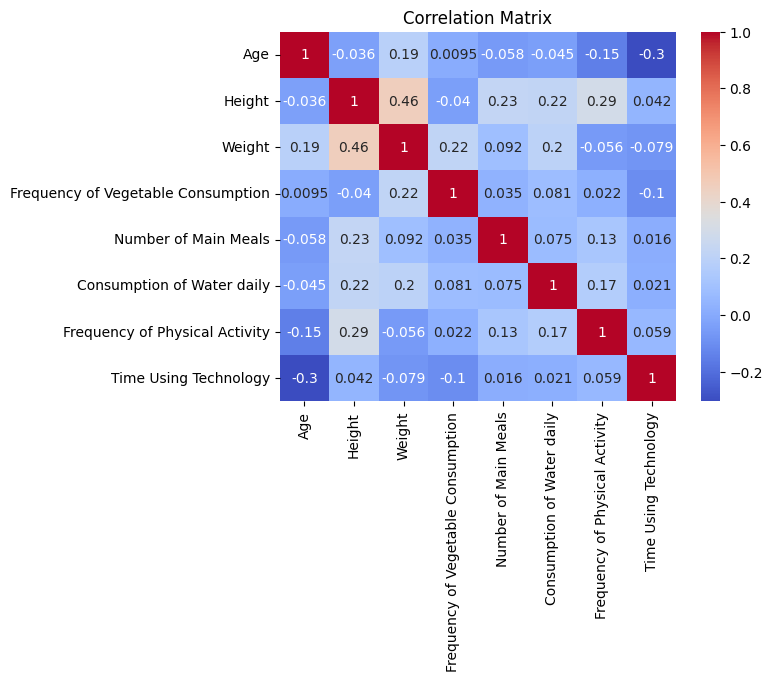

```python
selected_columns = ['Age', 'Height', 'Weight', 'Frequency of Vegetable Consumption', 'Number of Main Meals',
                    'Consumption of Water daily', 'Frequency of Physical Activity', 'Time Using Technology']
correlation_matrix = data[selected_columns].corr()
sns.heatmap(correlation_matrix, annot=True, cmap='coolwarm')
plt.title('Correlation Matrix')
plt.show()
```

Pattern Identification: Identify any patterns or trends in the data, such as the relationship between Age and Obesity Level.

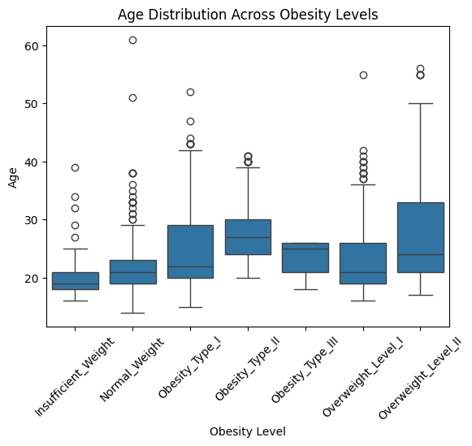

```python
sns.boxplot(x=data['Obesity Level'], y=data['Age'])
plt.title('Age Distribution Across Obesity Levels')
plt.xlabel('Obesity Level')
plt.ylabel('Age')
plt.xticks(rotation=45)
plt.show()
```

Anomaly Detection: Detect any anomalies or outliers in the data that might require further investigation.

```python
# Example: Checking for anomalies in weight
outliers = data[(data['Weight'] > data['Weight'].quantile(0.99))]
print(outliers)
```

```
      Gender  Age    Height      Weight Family History with Overweight  \
344     Male   18  1.870000  173.000000                            yes
502   Female   21  1.843419  165.057269                            yes
1814  Female   21  1.730113  152.094362                            yes
1826  Female   18  1.827730  152.720545                            yes
1838  Female   20  1.807340  155.872093                            yes
1854  Female   20  1.787195  151.975864                            yes
1897  Female   20  1.782714  154.618446                            yes
1898  Female   19  1.793824  160.935351                            yes
1909  Female   21  1.809871  152.394739                            yes
1910  Female   21  1.803677  160.639405                            yes
1925  Female   20  1.801478  151.417292                            yes
1926  Female   18  1.807576  152.567671                            yes
1949  Female   19  1.792833  152.435630                            yes
1950  Female   20  1.810427  152.217135                            yes
```

[output cut: 122 more lines]

Trend Analysis: Analyze trends over categorical variables, such as changes in obesity levels based on the frequency of physical activity.

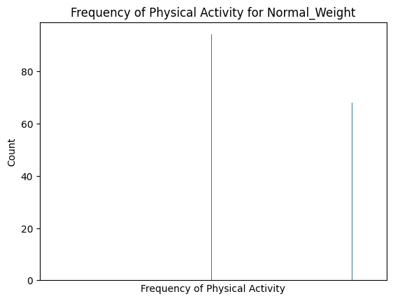

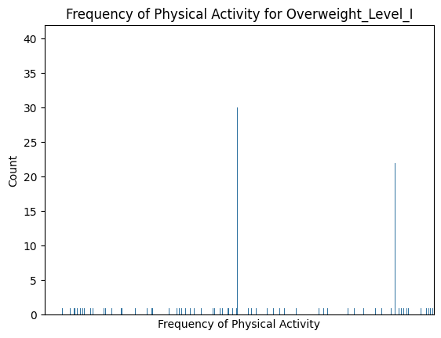

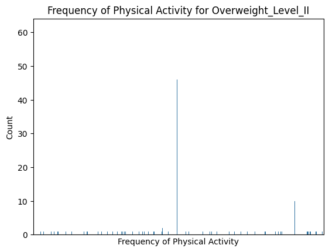

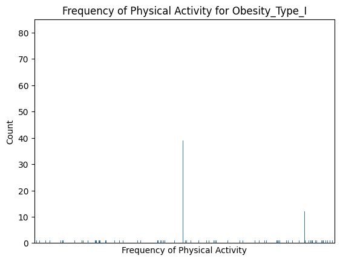

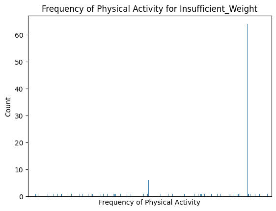

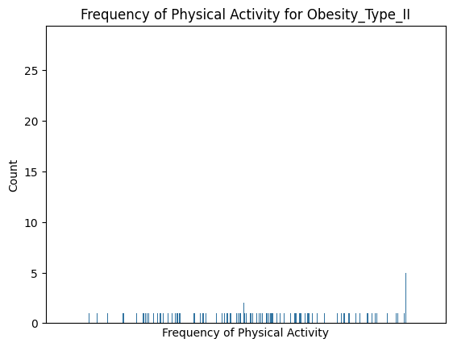

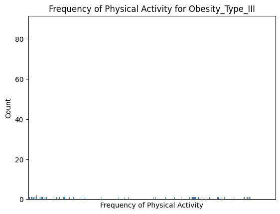

```python
obesity_levels = data['Obesity Level'].unique()
# Create a countplot for each obesity level
for obesity_level in obesity_levels:
    subset = data[data['Obesity Level'] == obesity_level]
    sns.countplot(data=subset, x='Frequency of Physical Activity')
    plt.xlabel('Frequency of Physical Activity')
    plt.xticks([])
    plt.ylabel('Count')
    plt.title(f'Frequency of Physical Activity for {obesity_level}')

    max_count = subset['Frequency of Physical Activity'].value_counts().max()
    buffer = 1.1 # Add a buffer to the maximum count for better visualization
    y_limit = max_count * buffer # Automatically adjust y-axis limit based on the maximum count
    plt.show()
```

## 4. Hypothesis Testing and Machine Learning

### 4.1 Formulating Hypotheses

Formulating hypotheses is an essential step before conducting statistical tests or building machine learning models. Hypotheses are statements that can be tested and validated or refuted based on data analysis.

Examples of Hypotheses:

-Hypothesis 1: There is a significant difference in the mean age of individuals across different obesity levels.

-Hypothesis 2: Higher frequency of physical activity is associated with lower obesity levels.

-Hypothesis 3: There is a significant relationship between family history of being overweight and the obesity level of individuals.

### 4.2 Hypothesis Testing

Hypothesis testing involves using statistical tests to determine whether there is enough evidence to support or refute a hypothesis. We will use appropriate tests based on the nature of the data and the hypotheses formulated.

Testing Hypothesis 1: There is a significant difference in the mean age of individuals across different obesity levels.

```python
#Test Used: ANOVA (Analysis of Variance)
from scipy.stats import f_oneway

obesity_levels = data['Obesity Level'].unique()
age_groups = [data['Age'][data['Obesity Level'] == level] for level in obesity_levels]

anova_result = f_oneway(*age_groups)
print(f"ANOVA result: F-statistic = {anova_result.statistic}, p-value = {anova_result.pvalue}")
```

```
ANOVA result: F-statistic = 72.66615001761727, p-value = 1.8330661456803647e-82
```

Testing Hypothesis 2: Higher frequency of physical activity is associated with lower obesity levels.

```python
# Test Used: Chi-Square Test of Independence
from scipy.stats import chi2_contingency

activity_obesity_table = pd.crosstab(data['Frequency of Physical Activity'], data['Obesity Level'])
chi2_result = chi2_contingency(activity_obesity_table)
print(f"Chi-Square Test result: Chi2-statistic = {chi2_result[0]}, p-value = {chi2_result[1]}")
```

```
Chi-Square Test result: Chi2-statistic = 7674.228568277183, p-value = 4.961175347728716e-06
```

Testing Hypothesis 3: There is a significant relationship between family history of being overweight and the obesity level of individuals.

```python
#Test Used: Chi-Square Test of Independence
family_obesity_table = pd.crosstab(data['Family History with Overweight'], data['Obesity Level'])
chi2_result = chi2_contingency(family_obesity_table)
print(f"Chi-Square Test result: Chi2-statistic = {chi2_result[0]}, p-value = {chi2_result[1]}")
```

```
Chi-Square Test result: Chi2-statistic = 617.7109928294774, p-value = 3.5241561087034105e-130
```

### 4.3 Machine Learning Models

Machine learning models are used to make predictions or uncover patterns in the data. We will implement and evaluate different models to analyze the data. The following model is called logistic regression, and it's used to predict categories of outputs, such as whether a set of inputs represents a cat or a dog. That's called a binary classification problem. If you have to predict more than 2 labels (cat, dog, bird, etc.) then that's a multiclass classification problem. Logistic regression is also a supervised learning algorithm, which means that we know what the actual labels of each observation are. Unsupervised learning algorithms are algorithms that are used when we don't know the actual labels associated with an observation. For example we know the observation has 4 legs is a mammal and is a common household pet, but we don't know if it's a cat or dog. In this case we have a multiclass classification problem because we make a prediction of one out of 7 different obesity levels. [Here's an article goin more in depth with logistic regression](https://www.ibm.com/topics/logistic-regression).

##### Data Preparation:

```python
from sklearn.model_selection import train_test_split
from sklearn.preprocessing import LabelEncoder

selected_columns = ['Age', 'Height', 'Weight', 'Frequency of Vegetable Consumption',
                    'Consumption of Water daily', 'Frequency of Physical Activity']

X = data[selected_columns]
y = data['Obesity Level']

# Convert categorical target to numerical using Label Encoding
y = LabelEncoder().fit_transform(y)

# Split the data into training and testing sets
X_train, X_test, y_train, y_test = train_test_split(X, y, test_size=0.2, random_state=42)
```

##### Model Training and Testing:

```
Logistic Regression Accuracy: 0.78
Logistic Regression Precision: 0.79
Logistic Regression Recall: 0.78
Logistic Regression F1 Score: 0.78
```

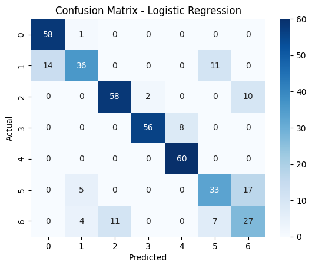

```python
from sklearn.linear_model import LogisticRegression
from sklearn.metrics import accuracy_score, precision_score, recall_score, f1_score, confusion_matrix
import seaborn as sns
import matplotlib.pyplot as plt

# Train the model
lr_model = LogisticRegression(max_iter=1000)
lr_model.fit(X_train, y_train)

# Make predictions
y_pred_lr = lr_model.predict(X_test)

# Calculate evaluation metrics
accuracy_lr = accuracy_score(y_test, y_pred_lr)
precision_lr = precision_score(y_test, y_pred_lr, average='weighted')
recall_lr = recall_score(y_test, y_pred_lr, average='weighted')
f1_lr = f1_score(y_test, y_pred_lr, average='weighted')

print(f"Logistic Regression Accuracy: {accuracy_lr:.2f}")
print(f"Logistic Regression Precision: {precision_lr:.2f}")
print(f"Logistic Regression Recall: {recall_lr:.2f}")
print(f"Logistic Regression F1 Score: {f1_lr:.2f}")

# Confusion Matrix
cm_lr = confusion_matrix(y_test, y_pred_lr)
sns.heatmap(cm_lr, annot=True, fmt='d', cmap='Blues')
plt.title('Confusion Matrix - Logistic Regression')
plt.xlabel('Predicted')
plt.ylabel('Actual')
plt.show()
```

##### Results Interpretation:

Accuracy: The proportion of correctly predicted instances out of the total instances.

```python
print(f"The accuracy of the logistic regression model is {accuracy_lr:.2f}.")
```

```
The accuracy of the logistic regression model is 0.78.
```

Precision: The proportion of true positive predictions out of all positive predictions.

```python
print(f"The precision of the logistic regression model is {precision_lr:.2f}.")
```

```
The precision of the logistic regression model is 0.79.
```

Recall: The proportion of true positive predictions out of all actual positive instances.

```python
print(f"The recall of the logistic regression model is {recall_lr:.2f}.")
```

```
The recall of the logistic regression model is 0.78.
```

##### Decision Tree

Decision trees are another supervised learning algorithm like logistic regression. They work by partitioning the data set into subsets that represent the most effective "decision" or split in the tree. It's a bit hard to describe it without visuals so [here's an article that describes decision trees in detail](https://scikit-learn.org/stable/modules/tree.html).

```python
from sklearn.tree import DecisionTreeClassifier
from sklearn.metrics import classification_report

dt_model = DecisionTreeClassifier(random_state=42)
dt_model.fit(X_train, y_train)
y_pred_dt = dt_model.predict(X_test)
print(f"Decision Tree Accuracy: {accuracy_score(y_test, y_pred_dt)}")
print(classification_report(y_test, y_pred_dt))
```

```
Decision Tree Accuracy: 0.9234449760765551
              precision    recall  f1-score   support

           0       0.97      0.97      0.97        59
           1       0.89      0.82      0.85        61
           2       0.97      0.94      0.96        70
           3       0.98      1.00      0.99        64
           4       0.98      1.00      0.99        60
           5       0.80      0.80      0.80        55
           6       0.83      0.92      0.87        49

    accuracy                           0.92       418
   macro avg       0.92      0.92      0.92       418
weighted avg       0.92      0.92      0.92       418
```

## Insight and Conclusion

The project emphasized the trade-offs between model simplicity and complexity. While logistic regression offered interpretability, the decision tree provided detailed insights into the data's structure, guiding more effective intervention strategies. The insights from this project are instrumental for health professionals and policymakers aiming to tackle obesity, showcasing the potential of machine learning in developing nuanced and effective health strategies. This foundation sets the stage for further exploration and application of advanced machine learning techniques in health data analytics.